# Fantasy Football Analyzer -- Team Roster Season Analysis

This notebook runs a **full end-to-end roster analysis for one team's season**, then applies the exact same analysis to **every team in the league** and compares the results with visualizations.

"End-to-end" means it exercises the whole pipeline described in `AGENTS.md`, not just Epic 7: Sleeper client -> `LeagueSnapshot` -> season matchups -> league analytics (Epic 6) -> the player-week fact table, player value, position strength, lineup efficiency, matchup player contribution, and manager lineup tendency analytics (Epic 7, FFA-064 through FFA-070).

It makes **live calls to the Sleeper API and to nflverse** (via the cached providers already built in `fantasy_analyzer.players`) -- nothing here uses test fixtures. This is exploratory/reporting code, not library code: per `AGENTS.md`, notebooks are for exploration and are not covered by the unit test suite.

## Prerequisites

This notebook needs a Jupyter kernel running the project's virtual environment, including the `matplotlib` dev extra used for the charts below:

```
.venv/bin/pip install -e ".[dev]"
.venv/bin/python -m ipykernel install --user --name fantasy-analyzer
```

Then select the `fantasy-analyzer` kernel for this notebook. The first run will download and cache nflverse's weekly player-stats file (`.cache/nflverse/player_stats.csv`) and the Sleeper player catalog (`.cache/sleeper/players.json`) -- subsequent runs reuse those caches.

## 1. Setup

```python
from __future__ import annotations

from IPython.display import Markdown, display
from matplotlib.colors import LinearSegmentedColormap
import matplotlib.pyplot as plt
import matplotlib.ticker as mticker
import pandas as pd

from fantasy_analyzer.analytics.league_analytics import build_league_analytics
from fantasy_analyzer.analytics.summary import build_league_summary
from fantasy_analyzer.league.season import derive_season_boundaries
from fantasy_analyzer.league.snapshot import load_league_snapshot
from fantasy_analyzer.matchups.loader import load_season_matchups
from fantasy_analyzer.matchups.outcomes import derive_season_outcomes
from fantasy_analyzer.matchups.pairing import pair_season_matchups
from fantasy_analyzer.matchups.season_matchups import build_season_matchup_df
from fantasy_analyzer.players.crosswalk import build_id_crosswalk
from fantasy_analyzer.players.lineup_tendencies import (
    build_bench_allocation_metrics,
    build_flex_usage_metrics,
    build_positional_preference_metrics,
    build_roster_construction_metrics,
    build_start_sit_tendency_metrics,
)
from fantasy_analyzer.players.matchup_contribution import (
    build_matchup_player_contributions,
    build_positional_matchup_advantage,
)
from fantasy_analyzer.players.nflverse_provider import NflverseWeeklyStatsProvider
from fantasy_analyzer.players.player_analytics import build_player_analytics
from fantasy_analyzer.players.player_week import build_player_week_fact_table
from fantasy_analyzer.sleeper.cache import get_players_cached
from fantasy_analyzer.sleeper.client import SleeperClient

pd.set_option("display.max_columns", None)
pd.set_option("display.width", 140)

# Per AGENTS.md: the primary development user, but code must not hard-code
# this into library logic -- it is only a notebook-local default. Change it
# to analyze a different Sleeper user.
SLEEPER_USERNAME = "schneidbaby"
SEASON = 2025

client = SleeperClient()
```

### Chart styling

A small, self-contained styling layer so every chart in this notebook reads as one system: a fixed categorical hue order (used only where color encodes *identity*, e.g. one team's actual-vs-optimal lines or a position breakdown), a single accent hue for plain magnitude/ranking bars, and a one-hue sequential ramp for the position-strength heatmap. Team-ranking bar charts deliberately do *not* try to give each of the league's 10 teams its own hue -- past ~8 series no fixed categorical order stays distinguishable, so identity there is carried by the axis labels instead, and color is just a single accent.

```python
# Fixed categorical hue order (blue, orange, aqua, yellow, magenta, green,
# violet, red) -- assign by *identity* (e.g. position), never by rank, and
# never reuse a slot for something else within one chart.
CATEGORICAL = [
    "#2a78d6", "#eb6834", "#1baf7a", "#eda100",
    "#e87ba4", "#008300", "#4a3aa7", "#e34948",
]
ACCENT = CATEGORICAL[0]
GOOD = "#0ca30c"
CRITICAL = "#d03b3b"

INK = "#0b0b0b"
INK_SECONDARY = "#52514e"
INK_MUTED = "#898781"
GRID = "#e1e0d9"
SURFACE = "#fcfcfb"

# Sequential single-hue (blue) ramp for magnitude encodings (heatmap cells).
SEQUENTIAL_BLUE = LinearSegmentedColormap.from_list(
    "sequential_blue", ["#cde2fb", "#3987e5", "#0d366b"]
)

POSITION_ORDER = ["QB", "RB", "WR", "TE", "K", "DEF"]
POSITION_COLORS = dict(zip(POSITION_ORDER, CATEGORICAL))


def style_ax(ax, title=None, ylabel=None):
    """Apply this notebook's shared chart chrome to one axes."""
    ax.set_facecolor(SURFACE)
    ax.figure.set_facecolor(SURFACE)
    ax.spines["top"].set_visible(False)
    ax.spines["right"].set_visible(False)
    ax.spines["left"].set_color(GRID)
    ax.spines["bottom"].set_color(GRID)
    ax.tick_params(colors=INK_SECONDARY, labelsize=9)
    ax.yaxis.grid(True, color=GRID, linewidth=0.8, zorder=0)
    ax.set_axisbelow(True)
    if title:
        ax.set_title(title, fontsize=11, color=INK, loc="left", pad=8, weight="bold")
    if ylabel:
        ax.set_ylabel(ylabel, fontsize=9, color=INK_SECONDARY)


def position_order_key(position: str) -> int:
    return POSITION_ORDER.index(position) if position in POSITION_ORDER else len(POSITION_ORDER)
```

## 2. Discover your leagues and pick one (FFA-003)

Same as `league_walkthrough.ipynb`: resolve your username to Sleeper's immutable `user_id`, list every league for `SEASON`, and pick a `league_id`.

```python
user = client.get_user(SLEEPER_USERNAME)
user_id = user["user_id"]

leagues = client.get_leagues(user_id=user_id, season=SEASON)
leagues_df = pd.DataFrame(
    [{"league_id": lg["league_id"], "name": lg["name"], "status": lg["status"]} for lg in leagues]
)
leagues_df
```

|  | league_id | name | status |
| --- | --- | --- | --- |
| 0 | 1283213576168837120 | BBC weird league | complete |
| 1 | 1268699066192101376 | NWC Guillotine League | complete |
| 2 | 1262800342051999744 | Just Here For The Zipline | complete |
| 3 | 1260307567133859840 | N(ew Wave) F(riends) L(eague) | complete |
| 4 | 1257477810625196032 | NWC FFL, est. 2011 | complete |

```python
LEAGUE_ID = leagues[3]["league_id"]

# 2025 fantasy season length. Sleeper doesn't expose "total weeks" directly
# (see league/season.py) -- this must be supplied per-season, not hardcoded
# into library logic.
TOTAL_WEEKS = 18

LEAGUE_ID
```

```
'1260307567133859840'
```

## 3. Build the league foundation (Epics 2-6)

One `LeagueSnapshot`, the normalized season of matchups, and `LeagueAnalytics` -- everything `league_walkthrough.ipynb` demonstrates in depth. This notebook just builds them once and moves straight to the roster-level analysis; see that notebook for the per-metric walkthrough of each piece.

```python
snapshot = load_league_snapshot(client, LEAGUE_ID)
summary = build_league_summary(snapshot, total_weeks=TOTAL_WEEKS)

boundaries = derive_season_boundaries(snapshot.league, total_weeks=TOTAL_WEEKS)
weeks = load_season_matchups(client, LEAGUE_ID, boundaries, season=snapshot.league.season)
pairings = pair_season_matchups(weeks)
outcomes = derive_season_outcomes(pairings)
season_matchup_df = build_season_matchup_df(outcomes, snapshot.teams_df)

try:
    winners_bracket_raw = client.get_winners_bracket(LEAGUE_ID)
    losers_bracket_raw = client.get_losers_bracket(LEAGUE_ID)
except Exception:
    winners_bracket_raw, losers_bracket_raw = None, None

league_analytics = build_league_analytics(
    season_matchup_df,
    snapshot.teams_df,
    winners_bracket_raw=winners_bracket_raw,
    losers_bracket_raw=losers_bracket_raw,
)

standings_df = summary.standings()
scoring_df = summary.scoring_summary()
allplay_df = league_analytics.all_play()
luck_df = league_analytics.schedule_luck()
consistency_df = league_analytics.consistency()
sos_df = league_analytics.strength_of_schedule()
power_df = league_analytics.power_rankings()
placements_df = league_analytics.final_placements()

print(f"{snapshot.league.name} -- season {snapshot.league.season} ({snapshot.league.status})")
print(f"{snapshot.league.total_rosters} teams, playoffs start week {snapshot.league.playoff_week_start}")
standings_df
```

```
N(ew Wave) F(riends) L(eague) -- season 2025 (complete)
10 teams, playoffs start week 15
```

|  | roster_id | owner_id | display_name | team_name | wins | losses | ties | win_pct | points_for | points_against | point_diff | rank |
| --- | --- | --- | --- | --- | --- | --- | --- | --- | --- | --- | --- | --- |
| 0 | 1 | 1124895994132406272 | callahanmancan | Riley's Little Ladds | 11 | 3 | 0 | 0.785714 | 1875.48 | 1673.96 | 201.52 | 1 |
| 1 | 4 | 1127727340412416000 | danerunning | Larry’s Call Girl | 10 | 4 | 0 | 0.714286 | 1996.38 | 1729.64 | 266.74 | 2 |
| 2 | 7 | 599792499258613760 | Deschi | Desch n Dee | 9 | 5 | 0 | 0.642857 | 1860.48 | 1744.90 | 115.58 | 3 |
| 3 | 6 | 1257880184422404096 | TaylorDucote | Live, Laugh, Jihad | 8 | 6 | 0 | 0.571429 | 1826.68 | 1797.12 | 29.56 | 4 |
| 4 | 5 | 1132821020680835072 | jsnesbit | Fumble for a Tumble | 8 | 6 | 0 | 0.571429 | 1729.74 | 1696.38 | 33.36 | 5 |
| 5 | 9 | 733854730526269440 | Sticks24 | Sanka ya Dead??? | 7 | 7 | 0 | 0.500000 | 1728.70 | 1768.42 | -39.72 | 6 |
| 6 | 2 | 1124901188417331200 | hankleeman | Riley Doesn’t Run | 6 | 8 | 0 | 0.428571 | 1935.72 | 1906.36 | 29.36 | 7 |
| 7 | 3 | 865610532865060864 | schneidbaby | Bar Rat Boyfriends | 4 | 10 | 0 | 0.285714 | 1789.56 | 1963.54 | -173.98 | 8 |
| 8 | 8 | 1128875516674605056 | sleepymegan | Larry’s Caretaker | 4 | 10 | 0 | 0.285714 | 1736.14 | 1924.74 | -188.60 | 9 |
| 9 | 10 | 1127725968589746176 | ayyeeohh | 10th st on top | 3 | 11 | 0 | 0.214286 | 1634.88 | 1908.70 | -273.82 | 10 |

## 4. Build the player-week fact table (FFA-060 through FFA-064)

The Epic 7 foundation every roster analysis below is built on: Sleeper's own weekly roster data (who was rostered, who started) joined against nflverse's raw weekly stats (via the Sleeper<->nflverse `gsis_id` crosswalk, FFA-062) and scored with this league's actual Sleeper scoring settings (FFA-063). One row per `(week, rostered player)` -- see `players/player_week.py` for the exact row universe and edge cases.

```python
player_catalog = get_players_cached(client)
id_crosswalk = build_id_crosswalk(player_catalog)
provider = NflverseWeeklyStatsProvider(id_crosswalk=id_crosswalk)

fact_table = build_player_week_fact_table(
    weeks, snapshot.teams_df, snapshot.players_df, provider, snapshot.scoring_settings
)
player_week_df = fact_table.player_week_df

if fact_table.unsupported_scoring_keys:
    print(f"WARNING -- unsupported scoring keys (points from these are NOT included): "
          f"{fact_table.unsupported_scoring_keys}")
else:
    print("Every scoring-settings category was mapped to a raw stat column.")

print(f"{len(player_week_df):,} player-week rows across {player_week_df['week'].nunique()} weeks")
player_week_df.head()
```

```
WARNING -- unsupported scoring keys (points from these are NOT included): ['blk_kick', 'def_st_ff', 'def_st_fum_rec', 'def_st_td', 'def_td', 'ff', 'fgm_0_19', 'fgm_20_29', 'fgm_30_39', 'fgm_40_49', 'fgm_50p', 'fgmiss', 'fum', 'fum_rec', 'fum_rec_td', 'int', 'pass_2pt', 'pts_allow_0', 'pts_allow_14_2…
2,795 player-week rows across 18 weeks
```

|  | season | week | roster_id | fantasy_team | sleeper_player_id | gsis_id | player_name | position | nfl_team | started | bench | completions | attempts | passing_yards | passing_tds | sack_fumbles_lost | carries | rushing_yards | rushing_tds | rushing_fumbles_lost | receptions | targets | receiving_yards | receiving_tds | receiving_fumbles_lost | fantasy_points |
| --- | --- | --- | --- | --- | --- | --- | --- | --- | --- | --- | --- | --- | --- | --- | --- | --- | --- | --- | --- | --- | --- | --- | --- | --- | --- | --- |
| 0 | 2025 | 1 | 1 | callahanmancan | 11560 | NaN | Caleb Williams | QB | CHI | False | True | NaN | NaN | NaN | NaN | NaN | NaN | NaN | NaN | NaN | NaN | NaN | NaN | NaN | NaN | 0.00 |
| 1 | 2025 | 1 | 1 | callahanmancan | 11620 | NaN | Rome Odunze | WR | CHI | False | True | NaN | NaN | NaN | NaN | NaN | NaN | NaN | NaN | NaN | NaN | NaN | NaN | NaN | NaN | 0.00 |
| 2 | 2025 | 1 | 1 | callahanmancan | 11635 | NaN | Ladd McConkey | WR | LAC | True | False | NaN | NaN | NaN | NaN | NaN | NaN | NaN | NaN | NaN | NaN | NaN | NaN | NaN | NaN | 0.00 |
| 3 | 2025 | 1 | 1 | callahanmancan | 12527 | NaN | Ashton Jeanty | RB | LV | True | False | NaN | NaN | NaN | NaN | NaN | NaN | NaN | NaN | NaN | NaN | NaN | NaN | NaN | NaN | 0.00 |
| 4 | 2025 | 1 | 1 | callahanmancan | 3294 | 00-0033077 | Dak Prescott | QB | DAL | True | False | 21.0 | 34.0 | 188.0 | 0.0 | 0.0 | 1.0 | 3.0 | 0.0 | 0.0 | 0.0 | 0.0 | 0.0 | 0.0 | 0.0 | 7.82 |

```python
player_analytics = build_player_analytics(
    player_week_df, snapshot.roster_positions, snapshot.league.total_rosters
)

player_season_df = player_analytics.player_season_df
position_summary_df = player_analytics.position_summary_df
lineup_efficiency_df = player_analytics.lineup_efficiency_df
roster_efficiency_df = player_analytics.roster_efficiency_df
player_value_df = player_analytics.player_value_df

roster_efficiency_df.sort_values("efficiency_pct", ascending=False)
```

|  | season | roster_id | fantasy_team | weeks_played | total_actual_points | total_optimal_points | total_bench_points | total_points_left_on_bench | efficiency_pct | suboptimal_weeks | suboptimal_week_pct | total_suboptimal_starts | total_suboptimal_sits |
| --- | --- | --- | --- | --- | --- | --- | --- | --- | --- | --- | --- | --- | --- |
| 9 | 2025 | 9 | Sticks24 | 18 | 226.86 | 226.86 | 0.00 | 0.00 | 1.000000 | 0 | 0.000000 | 2 | 0 |
| 5 | 2025 | 5 | jsnesbit | 18 | 566.52 | 566.52 | 0.00 | 0.00 | 1.000000 | 0 | 0.000000 | 10 | 0 |
| 8 | 2025 | 8 | sleepymegan | 18 | 607.52 | 611.02 | 3.50 | 3.50 | 0.994272 | 1 | 0.055556 | 6 | 1 |
| 6 | 2025 | 6 | TaylorDucote | 18 | 442.20 | 489.10 | 46.90 | 46.90 | 0.904110 | 4 | 0.222222 | 55 | 4 |
| 4 | 2025 | 4 | danerunning | 18 | 1116.76 | 1281.16 | 164.40 | 164.40 | 0.871679 | 11 | 0.611111 | 21 | 14 |
| 0 | 2025 | 1 | callahanmancan | 18 | 318.04 | 374.34 | 56.30 | 56.30 | 0.849602 | 5 | 0.277778 | 31 | 4 |
| 7 | 2025 | 7 | Deschi | 18 | 499.28 | 646.62 | 353.36 | 147.34 | 0.772138 | 12 | 0.666667 | 33 | 17 |
| 1 | 2025 | 10 | ayyeeohh | 18 | 402.32 | 522.12 | 119.80 | 119.80 | 0.770551 | 11 | 0.611111 | 31 | 12 |
| 3 | 2025 | 3 | schneidbaby | 18 | 329.80 | 517.00 | 187.20 | 187.20 | 0.637911 | 14 | 0.777778 | 23 | 16 |
| 2 | 2025 | 2 | hankleeman | 18 | 61.56 | 217.40 | 155.84 | 155.84 | 0.283165 | 13 | 0.722222 | 37 | 16 |

## 5. Matchup player contribution and lineup tendencies (FFA-069/FFA-070)

The two most recently landed Epic 7 tickets: which started players actually drove each week's win/loss margin (FFA-069), and each manager's roster construction, bench allocation, FLEX usage, start/sit discipline, and positional preferences over the season (FFA-070).

```python
contributions_df = build_matchup_player_contributions(season_matchup_df, player_week_df)
positional_advantage_df = build_positional_matchup_advantage(season_matchup_df, player_week_df)

roster_construction_df = build_roster_construction_metrics(player_week_df)
bench_allocation_df = build_bench_allocation_metrics(player_week_df)
flex_usage_df = build_flex_usage_metrics(player_week_df, snapshot.roster_positions)
start_sit_df = build_start_sit_tendency_metrics(player_week_df, snapshot.roster_positions)
positional_preference_df = build_positional_preference_metrics(player_week_df)

contributions_df.head()
```

|  | season | week | is_playoff | matchup_id | roster_id | fantasy_team | opponent_roster_id | opponent_fantasy_team | sleeper_player_id | player_name | position | fantasy_points | team_points | opponent_points | share_of_team_points | margin | result | contribution_rank |
| --- | --- | --- | --- | --- | --- | --- | --- | --- | --- | --- | --- | --- | --- | --- | --- | --- | --- | --- |
| 0 | 2025 | 1 | False | 3 | 1 | callahanmancan | 8 | sleepymegan | 5045 | Courtland Sutton | WR | 18.10 | 108.42 | 153.98 | 0.166943 | -45.56 | loss | 1 |
| 1 | 2025 | 1 | False | 3 | 1 | callahanmancan | 8 | sleepymegan | 3294 | Dak Prescott | QB | 7.82 | 108.42 | 153.98 | 0.072127 | -45.56 | loss | 2 |
| 2 | 2025 | 1 | False | 3 | 1 | callahanmancan | 8 | sleepymegan | 11635 | Ladd McConkey | WR | 0.00 | 108.42 | 153.98 | 0.000000 | -45.56 | loss | 3 |
| 3 | 2025 | 1 | False | 3 | 1 | callahanmancan | 8 | sleepymegan | 12527 | Ashton Jeanty | RB | 0.00 | 108.42 | 153.98 | 0.000000 | -45.56 | loss | 3 |
| 4 | 2025 | 1 | False | 3 | 1 | callahanmancan | 8 | sleepymegan | 7569 | Nico Collins | WR | 0.00 | 108.42 | 153.98 | 0.000000 | -45.56 | loss | 3 |

## 6. The team roster report

`build_team_report(roster_id)` is the "full end-to-end roster analysis for one team's season" -- it pulls every frame built above down to a single roster, in one place:

- identity and final standing (Epic 3)
- advanced league-analytics standing: power rank, all-play win rate, schedule luck, consistency, strength of schedule (Epic 6)
- **this roster's own players**: every player who was ever on this `roster_id` this season, their games rostered/started, total and per-game fantasy points *while on this roster* -- distinct from `player_season_df`'s player-level (not team-level) season totals, which can span a trade -- enriched with each player's league-wide replacement-value rank (FFA-068) for context
- weekly lineup efficiency and the season roster-efficiency summary (FFA-067)
- roster construction, bench allocation, and FLEX usage (FFA-070)
- weekly matchup player contributions (FFA-069)

It returns a dict of scalars (for the cross-team comparison table in section 7) plus the underlying per-team DataFrames (for the deep-dive charts right below).

```python
def build_team_report(roster_id: int) -> dict:
    """Full end-to-end roster analysis for one team's season.

    Combines standings/scoring, advanced league analytics, player-level
    value, weekly lineup efficiency, roster construction tendencies, and
    matchup player contributions -- everything built in sections 3-5 above,
    filtered down to a single roster_id. See the section 6 markdown cell
    for what each piece means.
    """
    team_row = snapshot.teams_df.loc[snapshot.teams_df["roster_id"] == roster_id].iloc[0]
    fantasy_team = team_row["display_name"]

    standings_row = standings_df.loc[standings_df["roster_id"] == roster_id].iloc[0]
    scoring_row = scoring_df.loc[scoring_df["roster_id"] == roster_id].iloc[0]
    power_row = power_df.loc[power_df["roster_id"] == roster_id].iloc[0]
    allplay_row = allplay_df.loc[allplay_df["roster_id"] == roster_id].iloc[0]
    luck_row = luck_df.loc[luck_df["roster_id"] == roster_id].iloc[0]
    consistency_row = consistency_df.loc[consistency_df["roster_id"] == roster_id].iloc[0]
    sos_row = sos_df.loc[sos_df["roster_id"] == roster_id].iloc[0]
    roster_eff_row = roster_efficiency_df.loc[roster_efficiency_df["roster_id"] == roster_id]
    start_sit_row = start_sit_df.loc[start_sit_df["roster_id"] == roster_id]

    team_player_weeks = player_week_df.loc[player_week_df["roster_id"] == roster_id].copy()
    # A handful of deep-bench/practice-squad players never resolve to a name
    # or position via either the provider join or the Sleeper catalog
    # fallback (see player_week.py's "Identity enrichment order") -- fall
    # back to the raw Sleeper player_id so they still get a readable label
    # instead of breaking the groupby key or a chart's string axis.
    team_player_weeks["player_name"] = team_player_weeks["player_name"].fillna(
        "Player " + team_player_weeks["sleeper_player_id"].astype(str)
    )
    team_player_weeks["position"] = team_player_weeks["position"].fillna("UNK")

    team_players = (
        team_player_weeks
        .groupby(["sleeper_player_id", "player_name", "position"], dropna=False)
        .agg(
            weeks_rostered=("week", "nunique"),
            weeks_started=("started", "sum"),
            total_points=("fantasy_points", "sum"),
            points_per_game=("fantasy_points", "mean"),
        )
        .reset_index()
        .sort_values("total_points", ascending=False)
        .reset_index(drop=True)
    )
    team_players = team_players.merge(
        player_value_df[["sleeper_player_id", "value_rank", "points_above_replacement"]],
        on="sleeper_player_id",
        how="left",
    )

    weekly_efficiency = (
        lineup_efficiency_df.loc[lineup_efficiency_df["roster_id"] == roster_id]
        .sort_values("week")
        .reset_index(drop=True)
    )
    position_summary = position_summary_df.loc[
        position_summary_df["fantasy_team"] == fantasy_team
    ].copy()
    position_summary["position_order"] = position_summary["position"].map(position_order_key)
    position_summary = position_summary.sort_values("position_order").reset_index(drop=True)

    roster_construction = roster_construction_df.loc[
        roster_construction_df["fantasy_team"] == fantasy_team
    ]
    contributions_team = contributions_df.loc[contributions_df["roster_id"] == roster_id]
    top_contributor_share = (
        contributions_team.loc[contributions_team["contribution_rank"] == 1, "share_of_team_points"]
        .mean()
    )

    placement_row = placements_df.loc[placements_df["roster_id"] == roster_id]

    return {
        "roster_id": roster_id,
        "fantasy_team": fantasy_team,
        "team_name": team_row["team_name"],
        "wins": int(standings_row["wins"]),
        "losses": int(standings_row["losses"]),
        "ties": int(standings_row["ties"]),
        "final_rank": int(standings_row["rank"]),
        "final_placement": (
            int(placement_row.iloc[0]["placement"]) if not placement_row.empty else None
        ),
        "points_per_game": scoring_row["points_per_game"],
        "power_rank": int(power_row["power_rank"]),
        "power_score": power_row["power_score"],
        "all_play_win_pct": allplay_row["all_play_win_pct"],
        "schedule_luck": luck_row["schedule_luck"],
        "consistency_cv": consistency_row["cv"],
        "sos_rank": int(sos_row["sos_rank"]),
        "efficiency_pct": (
            roster_eff_row.iloc[0]["efficiency_pct"] if not roster_eff_row.empty else float("nan")
        ),
        "points_left_on_bench": (
            roster_eff_row.iloc[0]["total_points_left_on_bench"]
            if not roster_eff_row.empty
            else float("nan")
        ),
        "suboptimal_starts_per_week": (
            start_sit_row.iloc[0]["suboptimal_starts_per_week"]
            if not start_sit_row.empty
            else float("nan")
        ),
        "top_player": team_players.iloc[0]["player_name"] if not team_players.empty else None,
        "top_player_points": (
            team_players.iloc[0]["total_points"] if not team_players.empty else float("nan")
        ),
        "top_contributor_share": top_contributor_share,
        "team_players": team_players,
        "weekly_efficiency": weekly_efficiency,
        "position_summary": position_summary,
        "roster_construction": roster_construction,
        "contributions": contributions_team,
    }
```

### Worked example: one team, in full

Before running this across the whole league, here is the complete report for a single team, with every chart: weekly actual-vs-optimal lineup points (the shaded gap is points left on the bench each week), points per game by position, the top point-scorers actually rostered this season, and how much of the team's weekly score its single best player typically carried.

**Bar Rat Boyfriends** -- 4-10-0 (final rank 8), 127.8 pts/game, power rank #7, lineup efficiency 63.8%, left 187.2 points on the bench all season.

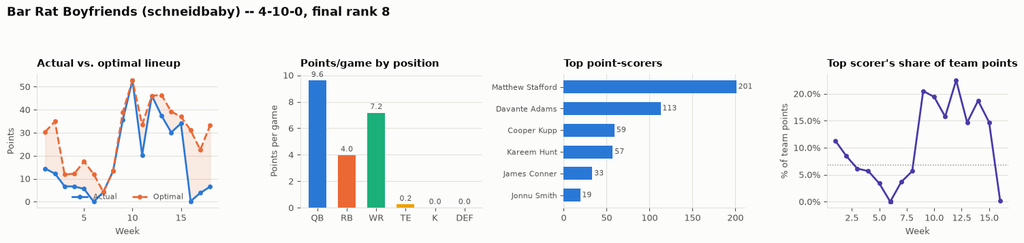

|  | sleeper_player_id | player_name | position | weeks_rostered | weeks_started | total_points | points_per_game | value_rank | points_above_replacement |
| --- | --- | --- | --- | --- | --- | --- | --- | --- | --- |
| 0 | 421 | Matthew Stafford | QB | 9 | 6 | 201.1 | 22.344444 | 14.0 | 92.02 |
| 1 | 2133 | Davante Adams | WR | 11 | 7 | 112.8 | 10.254545 | 4.0 | 147.30 |
| 2 | 4039 | Cooper Kupp | WR | 7 | 2 | 59.3 | 8.471429 | 29.0 | 21.50 |
| 3 | 4098 | Kareem Hunt | RB | 9 | 4 | 57.2 | 6.355556 | 34.0 | 4.80 |
| 4 | 4137 | James Conner | RB | 3 | 3 | 33.3 | 11.100000 | 31.0 | 13.65 |
| 5 | 4144 | Jonnu Smith | TE | 2 | 0 | 19.2 | 9.600000 | 32.0 | 13.00 |
| 6 | 4988 | Nick Chubb | RB | 3 | 2 | 18.5 | 6.166667 | 33.0 | 9.05 |
| 7 | 4037 | Chris Godwin Jr. | WR | 2 | 1 | 11.2 | 5.600000 | 26.0 | 29.50 |
| 8 | 5001 | Dalton Schultz | TE | 1 | 1 | 4.4 | 4.400000 | 40.0 | 0.00 |
| 9 | 10213 | Tre Tucker | WR | 1 | 1 | 0.0 | 0.000000 | NaN | NaN |

```python
def plot_team_dashboard(report: dict, figsize=(15, 3.6)):
    """Render the four-panel chart dashboard for one team's report."""
    fig, (ax_eff, ax_pos, ax_players, ax_share) = plt.subplots(1, 4, figsize=figsize)
    fig.patch.set_facecolor(SURFACE)

    # Panel 1: weekly actual vs optimal lineup points, gap shaded.
    weekly = report["weekly_efficiency"]
    if not weekly.empty:
        ax_eff.plot(weekly["week"], weekly["actual_points"], color=CATEGORICAL[0],
                    linewidth=2, marker="o", markersize=4, label="Actual", zorder=3)
        ax_eff.plot(weekly["week"], weekly["optimal_points"], color=CATEGORICAL[1],
                    linewidth=2, linestyle="--", marker="o", markersize=4,
                    label="Optimal", zorder=3)
        ax_eff.fill_between(weekly["week"], weekly["actual_points"], weekly["optimal_points"],
                             color=CATEGORICAL[1], alpha=0.12, zorder=1)
        ax_eff.legend(frameon=False, fontsize=8, loc="lower center",
                       ncol=2, labelcolor=INK_SECONDARY)
    style_ax(ax_eff, title="Actual vs. optimal lineup", ylabel="Points")
    ax_eff.set_xlabel("Week", fontsize=9, color=INK_SECONDARY)

    # Panel 2: points per game by position.
    pos = report["position_summary"]
    if not pos.empty:
        colors = [POSITION_COLORS.get(p, INK_MUTED) for p in pos["position"]]
        bars = ax_pos.bar(pos["position"], pos["points_per_game"], color=colors, width=0.6, zorder=3)
        ax_pos.bar_label(bars, fmt="%.1f", padding=2, fontsize=8, color=INK_SECONDARY)
    style_ax(ax_pos, title="Points/game by position", ylabel="Points per game")

    # Panel 3: top point-scorers actually rostered this season.
    top_players = report["team_players"].head(6).iloc[::-1]
    if not top_players.empty:
        bars = ax_players.barh(top_players["player_name"], top_players["total_points"],
                                color=ACCENT, height=0.6, zorder=3)
        ax_players.bar_label(bars, fmt="%.0f", padding=2, fontsize=8, color=INK_SECONDARY)
    style_ax(ax_players, title="Top point-scorers")
    ax_players.xaxis.grid(True, color=GRID, linewidth=0.8, zorder=0)
    ax_players.yaxis.grid(False)
    ax_players.tick_params(axis="y", labelsize=8)

    # Panel 4: weekly top-contributor share of team points.
    contrib = report["contributions"]
    top_each_week = contrib.loc[contrib["contribution_rank"] == 1].sort_values("week")
    if not top_each_week.empty:
        ax_share.plot(top_each_week["week"], top_each_week["share_of_team_points"] * 100,
                       color=CATEGORICAL[6], linewidth=2, marker="o", markersize=4, zorder=3)
        ax_share.axhline(report["top_contributor_share"] * 100, color=INK_MUTED,
                          linewidth=1, linestyle=":", zorder=2)
    style_ax(ax_share, title="Top scorer's share of team points", ylabel="% of team points")
    ax_share.set_xlabel("Week", fontsize=9, color=INK_SECONDARY)
    ax_share.yaxis.set_major_formatter(mticker.PercentFormatter())

    fig.suptitle(
        f"{report['team_name']} ({report['fantasy_team']}) -- "
        f"{report['wins']}-{report['losses']}-{report['ties']}, "
        f"final rank {report['final_rank']}",
        fontsize=13, color=INK, weight="bold", x=0.01, ha="left",
    )
    fig.tight_layout(rect=[0, 0, 1, 0.90])
    return fig


example_roster_id = int(
    snapshot.teams_df.loc[snapshot.teams_df["owner_id"] == user_id, "roster_id"].iloc[0]
)
example_report = build_team_report(example_roster_id)

display(Markdown(
    f"**{example_report['team_name']}** -- {example_report['wins']}-{example_report['losses']}-"
    f"{example_report['ties']} (final rank {example_report['final_rank']}), "
    f"{example_report['points_per_game']:.1f} pts/game, power rank "
    f"#{example_report['power_rank']}, lineup efficiency "
    f"{example_report['efficiency_pct']:.1%}, left "
    f"{example_report['points_left_on_bench']:.1f} points on the bench all season."
))
_ = plot_team_dashboard(example_report)
plt.show()

example_report["team_players"].head(10)
```

## 7. Apply the same analysis to every team

Running `build_team_report` once per `roster_id` produces the identical dashboard for every team in the league -- the exact analysis above, just looped. Each team's headline (record, points/game, efficiency) prints above its dashboard so the whole league can be scanned top to bottom; the scalar fields from every report are also collected into `league_comparison_df` for the cross-team charts in section 8.

Riley's Little Ladds (callahanmancan)

11-3-0, final rank 1 · 134.0 pts/game · power rank #2 · lineup efficiency 85.0% · top scorer **Courtland Sutton** (218 pts)

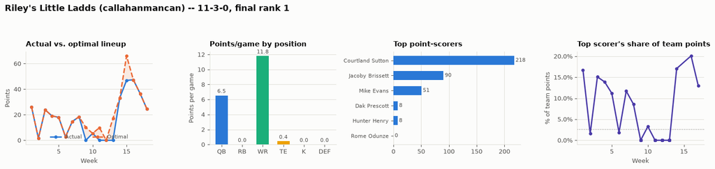

Riley Doesn’t Run (hankleeman)

6-8-0, final rank 7 · 138.3 pts/game · power rank #4 · lineup efficiency 28.3% · top scorer **Aaron Jones** (119 pts)

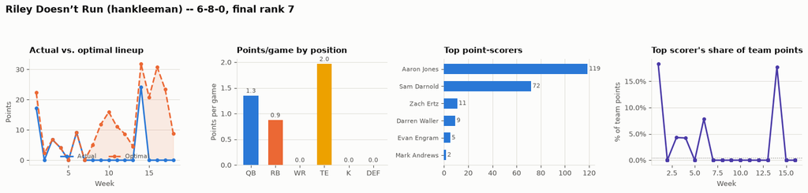

Bar Rat Boyfriends (schneidbaby)

4-10-0, final rank 8 · 127.8 pts/game · power rank #7 · lineup efficiency 63.8% · top scorer **Matthew Stafford** (201 pts)

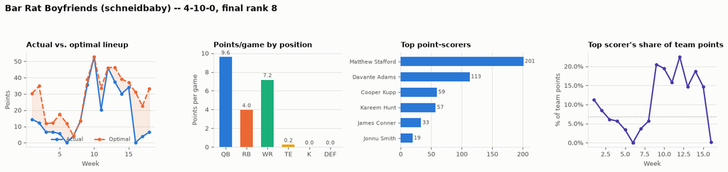

Larry’s Call Girl (danerunning)

10-4-0, final rank 2 · 142.6 pts/game · power rank #1 · lineup efficiency 87.2% · top scorer **Christian McCaffrey** (417 pts)

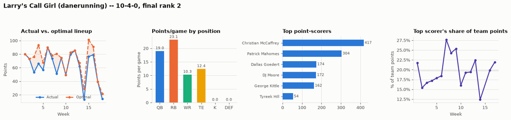

Fumble for a Tumble (jsnesbit)

8-6-0, final rank 5 · 123.6 pts/game · power rank #9 · lineup efficiency 100.0% · top scorer **Josh Allen** (383 pts)

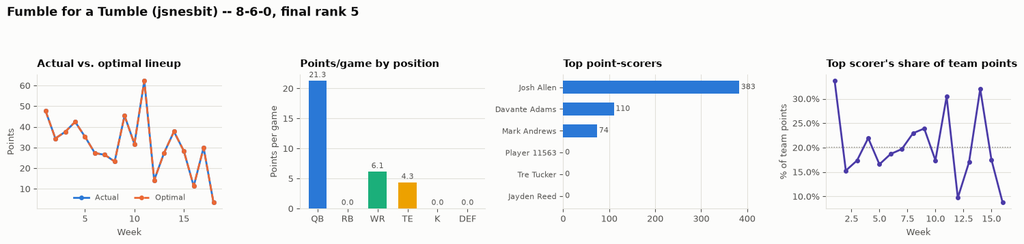

Live, Laugh, Jihad (TaylorDucote)

8-6-0, final rank 4 · 130.5 pts/game · power rank #5 · lineup efficiency 90.4% · top scorer **Saquon Barkley** (230 pts)

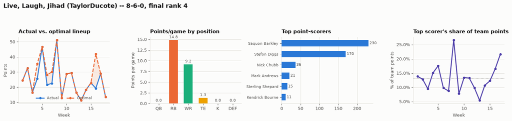

Desch n Dee (Deschi)

9-5-0, final rank 3 · 132.9 pts/game · power rank #3 · lineup efficiency 77.2% · top scorer **Jared Goff** (313 pts)

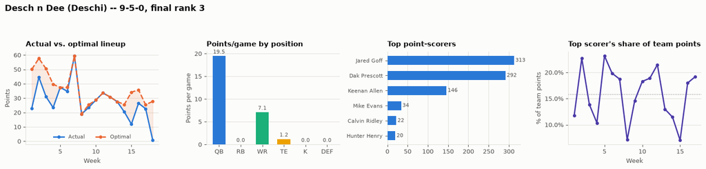

Larry’s Caretaker (sleepymegan)

4-10-0, final rank 9 · 124.0 pts/game · power rank #10 · lineup efficiency 99.4% · top scorer **Baker Mayfield** (290 pts)

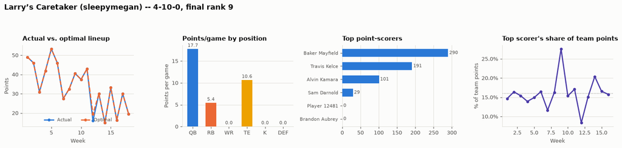

Sanka ya Dead??? (Sticks24)

7-7-0, final rank 6 · 123.5 pts/game · power rank #6 · lineup efficiency 100.0% · top scorer **Lamar Jackson** (227 pts)

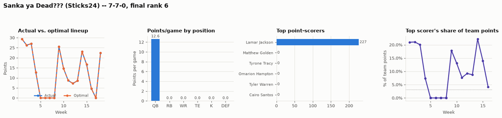

10th st on top (ayyeeohh)

3-11-0, final rank 10 · 116.8 pts/game · power rank #8 · lineup efficiency 77.1% · top scorer **Derrick Henry** (280 pts)

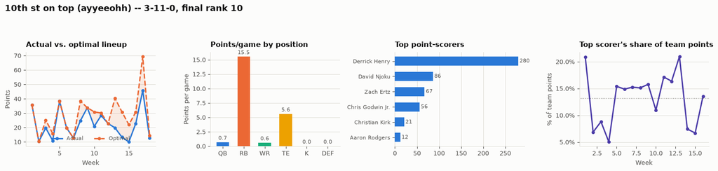

|  | roster_id | fantasy_team | team_name | wins | losses | ties | final_rank | final_placement | points_per_game | power_rank | power_score | all_play_win_pct | schedule_luck | consistency_cv | sos_rank | efficiency_pct | points_left_on_bench | suboptimal_starts_per_week | top_player | top_player_points | top_contributor_share |
| --- | --- | --- | --- | --- | --- | --- | --- | --- | --- | --- | --- | --- | --- | --- | --- | --- | --- | --- | --- | --- | --- |
| 0 | 1 | callahanmancan | Riley's Little Ladds | 11 | 3 | 0 | 1 | 3 | 133.962857 | 2 | 0.819834 | 0.543210 | 3.308642 | 0.186214 | 9 | 0.849602 | 56.30 | 1.722222 | Courtland Sutton | 217.70 | 0.025774 |
| 1 | 4 | danerunning | Larry’s Call Girl | 10 | 4 | 0 | 2 | 1 | 142.598571 | 1 | 1.851051 | 0.679012 | 1.135802 | 0.192484 | 10 | 0.871679 | 164.40 | 1.166667 | Christian McCaffrey | 416.60 | 0.197468 |
| 2 | 7 | Deschi | Desch n Dee | 9 | 5 | 0 | 3 | 4 | 132.891429 | 3 | 0.733190 | 0.574074 | 0.240741 | 0.212616 | 6 | 0.772138 | 147.34 | 1.833333 | Jared Goff | 313.06 | 0.158578 |
| 3 | 6 | TaylorDucote | Live, Laugh, Jihad | 8 | 6 | 0 | 4 | 2 | 130.477143 | 5 | 0.205494 | 0.500000 | 1.500000 | 0.174802 | 5 | 0.904110 | 46.90 | 3.055556 | Saquon Barkley | 230.30 | 0.132165 |
| 4 | 5 | jsnesbit | Fumble for a Tumble | 8 | 6 | 0 | 5 | 6 | 123.552857 | 9 | -0.951621 | 0.376543 | 1.975309 | 0.180798 | 7 | 1.000000 | 0.00 | 0.555556 | Josh Allen | 382.62 | 0.201877 |
| 5 | 9 | Sticks24 | Sanka ya Dead??? | 7 | 7 | 0 | 6 | 5 | 123.478571 | 6 | -0.468620 | 0.444444 | 0.888889 | 0.196052 | 1 | 1.000000 | 0.00 | 0.111111 | Lamar Jackson | 226.86 | 0.031964 |
| 6 | 2 | hankleeman | Riley Doesn’t Run | 6 | 8 | 0 | 7 | 2 | 138.265714 | 4 | 0.397709 | 0.555556 | -1.888889 | 0.245126 | 8 | 0.283165 | 155.84 | 2.055556 | Aaron Jones | 118.70 | 0.004562 |
| 7 | 3 | schneidbaby | Bar Rat Boyfriends | 4 | 10 | 0 | 8 | 3 | 127.825714 | 7 | -0.537170 | 0.475309 | -2.604938 | 0.191493 | 3 | 0.637911 | 187.20 | 1.277778 | Matthew Stafford | 201.10 | 0.068332 |
| 8 | 8 | sleepymegan | Larry’s Caretaker | 4 | 10 | 0 | 9 | 1 | 124.010000 | 10 | -1.408106 | 0.382716 | -2.123457 | 0.242835 | 2 | 0.994272 | 3.50 | 0.333333 | Baker Mayfield | 289.92 | 0.159878 |
| 9 | 10 | ayyeeohh | 10th st on top | 3 | 11 | 0 | 10 | 4 | 116.777143 | 8 | -0.641761 | 0.469136 | -2.506173 | 0.204566 | 4 | 0.770551 | 119.80 | 1.722222 | Derrick Henry | 279.50 | 0.132013 |

```python
reports = {}
comparison_rows = []

for roster_id in sorted(snapshot.teams_df["roster_id"]):
    report = build_team_report(roster_id)
    reports[roster_id] = report

    comparison_rows.append({
        key: value
        for key, value in report.items()
        if key not in ("team_players", "weekly_efficiency", "position_summary",
                        "roster_construction", "contributions")
    })

    display(Markdown(
        f"### {report['team_name']} ({report['fantasy_team']})\n"
        f"{report['wins']}-{report['losses']}-{report['ties']}, final rank "
        f"{report['final_rank']} &middot; {report['points_per_game']:.1f} pts/game &middot; "
        f"power rank #{report['power_rank']} &middot; lineup efficiency "
        f"{report['efficiency_pct']:.1%} &middot; top scorer **{report['top_player']}** "
        f"({report['top_player_points']:.0f} pts)"
    ))
    _ = plot_team_dashboard(report)
    plt.show()

league_comparison_df = pd.DataFrame(comparison_rows).sort_values("final_rank").reset_index(drop=True)
league_comparison_df
```

## 8. Comparing teams across the league

The per-team dashboards above are read one at a time; these charts put every team on the same axes. Team-ranking bar charts use a single accent hue -- with 10 teams there is no fixed categorical order that stays distinguishable, so identity is carried by the axis labels (see the styling note in section 1), and each bar is also directly labeled with its value.

Reminder from section 4: `K`/`DEF` fantasy points are understated all through this notebook (their real scoring is mostly tiered/bonus categories this league's provider pipeline doesn't carry), so treat the `K`/`DEF` columns/rows in the position-strength heatmap and the roster composition chart below as directional, not literal.

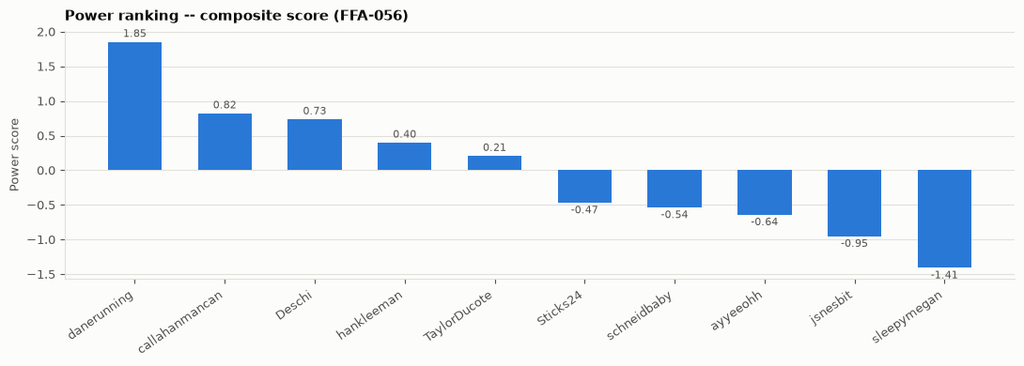

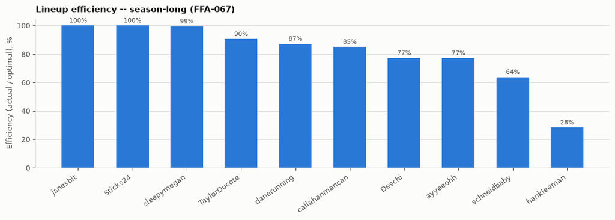

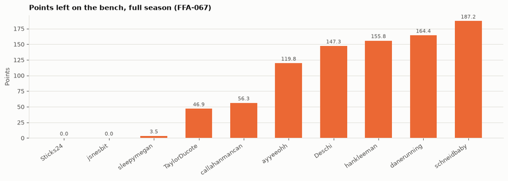

```python
def ranked_bar(df, value_col, label_col, title, ylabel, fmt="%.1f",
               ascending=False, color=ACCENT, figsize=(11, 4)):
    """A single-hue, directly-labeled bar chart ranking every team by one metric."""
    ordered = df.sort_values(value_col, ascending=ascending)
    fig, ax = plt.subplots(figsize=figsize)
    bars = ax.bar(ordered[label_col], ordered[value_col], color=color, width=0.6, zorder=3)
    ax.bar_label(bars, fmt=fmt, padding=2, fontsize=8, color=INK_SECONDARY)
    style_ax(ax, title=title, ylabel=ylabel)
    ax.tick_params(axis="x", labelrotation=35)
    for label in ax.get_xticklabels():
        label.set_ha("right")
    fig.tight_layout()
    return fig


_ = ranked_bar(
    league_comparison_df, "power_score", "fantasy_team",
    "Power ranking -- composite score (FFA-056)", "Power score", fmt="%.2f",
)
plt.show()

efficiency_pct_display = league_comparison_df.assign(
    efficiency_pct_100=league_comparison_df["efficiency_pct"] * 100
)
_ = ranked_bar(
    efficiency_pct_display, "efficiency_pct_100", "fantasy_team",
    "Lineup efficiency -- season-long (FFA-067)", "Efficiency (actual / optimal), %",
    fmt="%.0f%%",
)
plt.show()

_ = ranked_bar(
    league_comparison_df, "points_left_on_bench", "fantasy_team",
    "Points left on the bench, full season (FFA-067)", "Points",
    ascending=True, color=CATEGORICAL[1],
)
plt.show()
```

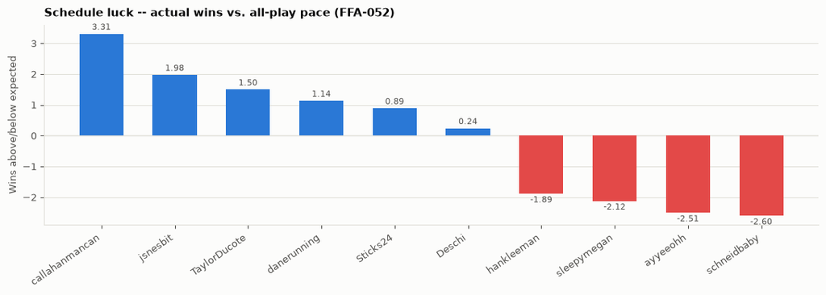

```python
# Schedule luck is naturally signed around zero -- diverging blue/red reads
# better here than a single accent hue: blue (favorable) vs. red
# (unfavorable), centered at 0.
ordered_luck = league_comparison_df.sort_values("schedule_luck", ascending=False)
colors = [CATEGORICAL[0] if v >= 0 else CATEGORICAL[7] for v in ordered_luck["schedule_luck"]]

fig, ax = plt.subplots(figsize=(11, 4))
bars = ax.bar(ordered_luck["fantasy_team"], ordered_luck["schedule_luck"], color=colors,
              width=0.6, zorder=3)
ax.bar_label(bars, fmt="%.2f", padding=2, fontsize=8, color=INK_SECONDARY)
ax.axhline(0, color=GRID, linewidth=1, zorder=2)
style_ax(ax, title="Schedule luck -- actual wins vs. all-play pace (FFA-052)", ylabel="Wins above/below expected")
ax.tick_params(axis="x", labelrotation=35)
for label in ax.get_xticklabels():
    label.set_ha("right")
fig.tight_layout()
plt.show()
```

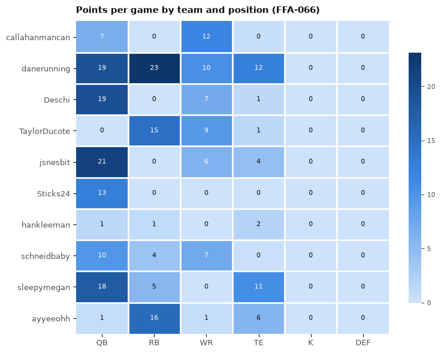

```python
# Position strength heatmap: team x position, points per game, one sequential
# hue (magnitude, not identity) -- brighter/darker means more points.
pivot = position_summary_df.pivot_table(
    index="fantasy_team", columns="position", values="points_per_game", aggfunc="first"
)
pivot = pivot.reindex(columns=[p for p in POSITION_ORDER if p in pivot.columns])
pivot = pivot.loc[
    league_comparison_df.sort_values("final_rank")["fantasy_team"].tolist()
]

fig, ax = plt.subplots(figsize=(8, 6))
im = ax.imshow(pivot.values, cmap=SEQUENTIAL_BLUE, aspect="auto")
ax.set_xticks(range(len(pivot.columns)))
ax.set_xticklabels(pivot.columns, fontsize=9, color=INK_SECONDARY)
ax.set_yticks(range(len(pivot.index)))
ax.set_yticklabels(pivot.index, fontsize=9, color=INK_SECONDARY)
ax.spines[:].set_visible(False)
ax.set_xticks([x - 0.5 for x in range(1, len(pivot.columns))], minor=True)
ax.set_yticks([y - 0.5 for y in range(1, len(pivot.index))], minor=True)
ax.grid(which="minor", color=SURFACE, linewidth=2)
ax.tick_params(which="minor", length=0)

for i in range(pivot.shape[0]):
    for j in range(pivot.shape[1]):
        value = pivot.values[i, j]
        if pd.notna(value):
            # Light text on the darkest cells, dark text elsewhere -- keeps
            # every label readable against the sequential ramp underneath it.
            text_color = SURFACE if value > pivot.values[~pd.isna(pivot.values)].mean() * 1.3 else INK
            ax.text(j, i, f"{value:.0f}", ha="center", va="center", fontsize=8, color=text_color)

ax.set_title("Points per game by team and position (FFA-066)", fontsize=11, color=INK,
             loc="left", pad=10, weight="bold")
cbar = fig.colorbar(im, ax=ax, shrink=0.8)
cbar.ax.tick_params(labelsize=8, colors=INK_SECONDARY)
cbar.outline.set_visible(False)
fig.tight_layout()
plt.show()
```

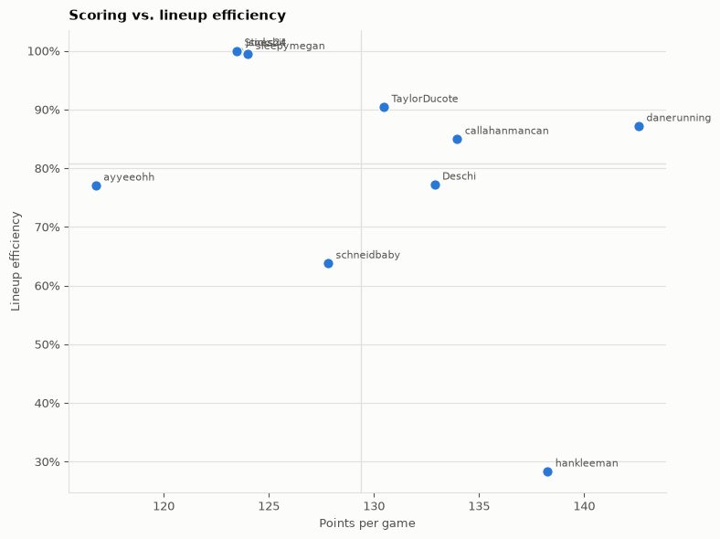

```python
# Lineup efficiency vs. scoring -- one dot per team, directly labeled (with
# only 10 points, a legend would cost more than it explains).
fig, ax = plt.subplots(figsize=(8, 6))
ax.scatter(league_comparison_df["points_per_game"], league_comparison_df["efficiency_pct"],
           color=ACCENT, s=70, zorder=3, edgecolor=SURFACE, linewidth=1)
for _, row in league_comparison_df.iterrows():
    ax.annotate(row["fantasy_team"], (row["points_per_game"], row["efficiency_pct"]),
                textcoords="offset points", xytext=(6, 4), fontsize=8, color=INK_SECONDARY)
ax.axvline(league_comparison_df["points_per_game"].mean(), color=GRID, linewidth=1, zorder=1)
ax.axhline(league_comparison_df["efficiency_pct"].mean(), color=GRID, linewidth=1, zorder=1)
ax.yaxis.set_major_formatter(mticker.PercentFormatter(xmax=1))
style_ax(ax, title="Scoring vs. lineup efficiency", ylabel="Lineup efficiency")
ax.set_xlabel("Points per game", fontsize=9, color=INK_SECONDARY)
fig.tight_layout()
plt.show()
```

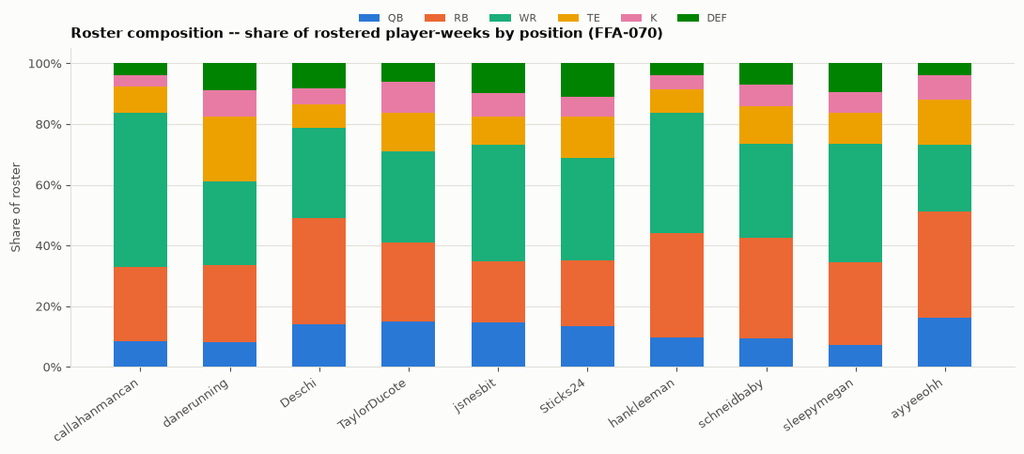

```python
# Roster composition: share of a team's rostered player-weeks spent at each
# position, 100%-stacked -- fixed position colors carry identity here since
# there are only 6 positions, well inside the categorical order's safe range.
composition = roster_construction_df.pivot_table(
    index="fantasy_team", columns="position", values="roster_share", aggfunc="first"
).fillna(0)
composition = composition.reindex(columns=[p for p in POSITION_ORDER if p in composition.columns])
composition = composition.loc[league_comparison_df.sort_values("final_rank")["fantasy_team"].tolist()]

fig, ax = plt.subplots(figsize=(11, 5))
bottom = pd.Series(0.0, index=composition.index)
for position in composition.columns:
    values = composition[position]
    ax.bar(composition.index, values, bottom=bottom, label=position,
           color=POSITION_COLORS.get(position, INK_MUTED), width=0.6, zorder=3)
    bottom = bottom + values

ax.legend(frameon=False, fontsize=8, ncol=len(composition.columns), loc="upper center",
          bbox_to_anchor=(0.5, 1.14), labelcolor=INK_SECONDARY)
ax.yaxis.set_major_formatter(mticker.PercentFormatter(xmax=1))
style_ax(ax, title="Roster composition -- share of rostered player-weeks by position (FFA-070)",
         ylabel="Share of roster")
ax.tick_params(axis="x", labelrotation=35)
for label in ax.get_xticklabels():
    label.set_ha("right")
fig.tight_layout()
plt.show()
```

## Summary

- `build_team_report(roster_id)` in section 6 composes the full Epic 1-7 pipeline -- league snapshot, matchup normalization, league analytics, the player-week fact table, player value, position strength, lineup efficiency, matchup player contribution, and lineup tendencies -- into one roster-level analysis.
- Section 7 applies it to every `roster_id` in the league and collects the results into `league_comparison_df`.
- Section 8 compares teams directly: power ranking, lineup efficiency, bench points wasted, schedule luck, position strength (heatmap), scoring vs. efficiency, and roster composition.
- Every metric used here is defined and tested in its own module under `src/fantasy_analyzer/analytics/` and `src/fantasy_analyzer/players/` -- this notebook adds no new metrics, only composition and visualization.